# Puppy Dog Eyes: Finding Influence in Pet Adoption

## by Zaid Khalid

[figure not shown]

On September 16, 2017, my family adopted Zazu. Zazu, pictured above, is a brown mackerel tabby and was only 6 months young when he arrived at our house. The day before, a family friend of ours told us he was in need of a forever home after his original owners were suffering major allergy problems in his presence. My mother is the sole decision-maker in such matters decided she would brave her fears of anything on four legs and went to go find out what beast awaits her. When she arrived, she felt very little threat from the little guy whose attention span was smaller than his little toe. The next day he became our first four-legged family member. Exactly a year later, in her search for a companion for Zazu and for her own girl cat, mom rescued Zoya and Zeno from a local animal rescue. Like many families, Zoya was planned, but Zeno was not. Apparently, when mom went to take a look at her newest baby, she met eyes with Zeno and instantly fell in love. I was surprised. Not by his looks, but that his "puppy dog" eyes worked on her when mine usually don't.

So that's where the interest in this tutorial arose. I wanted to see just how likely it is for puppy dog eyes to affect adoption rates. Perhaps there are other factors that independently influence adoption. And if these factors do exist, are they increasing or decreasing with every year. I will perform my testing and analyses using data from Austin Animal Center (AAC) Shelter Intakes and Outcomes, a dataset courtesy of the AAC hosted on [Kaggle](https://www.kaggle.com/aaronschlegel/austin-animal-center-shelter-intakes-and-outcomes). "The Austin Animal Center is the largest no-kill animal shelter in the United States that provides care and shelter to over 18,000 animals each year." The dataset presents approximately 80,000 shelter animal intakes and outcomes spanning from the end of 2013 to the beginning of 2018.

This tutorial will cover:

- Tidying the Data
- Exploratory Data Analysis and Visualization
- Data Transformation
- Regression Analysis and Visualization
- Classification
- Summarize Findings

Language: Python 3  
Libraries: pandas, numpy, scikit-learn, matplotlib, seaborn

## Tidying the Data

Let's prepare the dataset for analysis on adoption. I adjusted the columns for only the most useful variables. I renamed the variables accordingly. I dropped the rows where the animal was not a cat or dog because I believe only traditional domestic animals can display puppy dog eyes.

For the unclear categories, DaysIn is days in the shelter and YearOut is the year the animal met their outcome.

```python
import pandas as pd
import numpy as np
from sklearn import preprocessing
from sklearn import datasets
from sklearn.linear_model import LinearRegression as LinReg
from sklearn.preprocessing import PolynomialFeatures as PolyFeat
import matplotlib.pyplot as plt
import seaborn as sns

# Download CSV, read in through pandas, select desired columns, rename columns to something more meaningful
data = pd.read_csv("aac_intakes_outcomes.csv"),
data = data[0]
data = data[['animal_type', 'age_upon_outcome_(years)', 'age_upon_outcome_age_group', 'sex_upon_outcome', 'breed', 'color', 'time_in_shelter_days', 'outcome_year', 'outcome_type']]
data.columns = ['Animal', 'Age', 'AgeGrp', 'Sex', 'Breed', 'Color', 'DaysIn', 'YearOut', 'Outcome']

# Replace the Outcome column with a binary column for adoption
adopted = data['Outcome'] == 'Adoption'
data['Outcome'] = adopted
data.rename(columns = {'Outcome':'Adopted'}, inplace = True)

# Disregard any rows where the animal is not a dog or cat
data = data.drop(data[(data.Animal == 'Bird') | (data.Animal == 'Other')].index)

display(data.head())
display(data.shape)
```

|  | Animal | Age | AgeGrp | Sex | Breed | Color | DaysIn | YearOut | Adopted |
| --- | --- | --- | --- | --- | --- | --- | --- | --- | --- |
| 0 | Dog | 10.0 | (7.5, 10.0] | Neutered Male | Spinone Italiano Mix | Yellow/White | 0.588194 | 2017 | False |
| 1 | Dog | 7.0 | (5.0, 7.5] | Neutered Male | Spinone Italiano Mix | Yellow/White | 1.259722 | 2014 | False |
| 2 | Dog | 6.0 | (5.0, 7.5] | Neutered Male | Spinone Italiano Mix | Yellow/White | 1.113889 | 2014 | False |
| 3 | Dog | 10.0 | (7.5, 10.0] | Neutered Male | Dachshund | Tricolor | 4.970139 | 2014 | False |
| 4 | Dog | 16.0 | (15.0, 17.5] | Neutered Male | Shetland Sheepdog | Brown/White | 0.119444 | 2013 | False |

```
(74905, 9)
```

## EDA and Visualization

According to the [ASPCA](https://www.aspca.org/animal-homelessness/shelter-intake-and-surrender/pet-statistics), every year, 6.5 million pets are registered in U.S. animal shelters. Approximately 3.3 million dogs and 3.2 million cats. Although 1.5 million shelter animals are euthanized every year, double that figure are being adopted as well, 1.6 million dogs and 1.6 million cats. Since 2011, the number of euthanizations each year has decreased from 2.6 million. This is mostly due to a rise in shelter adoptions.

Let's see how true this is by measuring the frequency distribution of shelter adoptions per year.

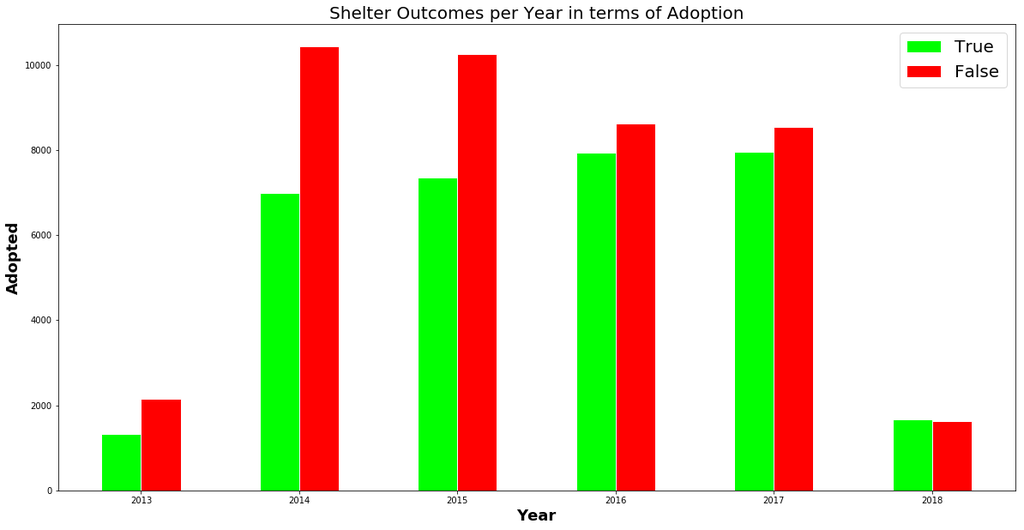

```python
# Sort dataframes by year, one for Adopted=True, other for Adopted=False
td = data.groupby(['YearOut'], as_index=False)['Adopted'].sum()
f = data.loc[data['Adopted'] == False]
fd = f.groupby(['YearOut'], as_index=False)['Adopted'].count()

barWidth = 0.25
plt.figure(figsize=(20,10))

bars1 = td['Adopted']
bars2 = fd['Adopted']

r1 = np.arange(len(bars1))
r2 = [x + barWidth for x in r1]

plt.bar(r1, bars1, color='#00ff00', width=barWidth, edgecolor='white', label='True')
plt.bar(r2, bars2, color='#ff0000', width=barWidth, edgecolor='white', label='False')

plt.title('Shelter Outcomes per Year in terms of Adoption', fontsize=20)
plt.xlabel('Year', fontweight='bold', fontsize=18)
plt.ylabel('Adopted', fontweight='bold', fontsize=18)
plt.xticks([r + barWidth/2 for r in range(len(bars1))], fd['YearOut'])

plt.legend(fontsize=20)
plt.rc('xtick', labelsize=20)
plt.rc('ytick', labelsize=20)
plt.show()
```

The data seems to verify the above statement, even with the minimal amount of data provided from 2013 and 2018. Over the years, the gap between adoption and non-adoption is closing. 2018 even shows the start of a balance between adoption and non-adoption.

Now that we know that adoption is on the rise, let's try and find the leading factors in adoption. To do so, let's start by plotting the correlation between age groups and adoption rate for every year.

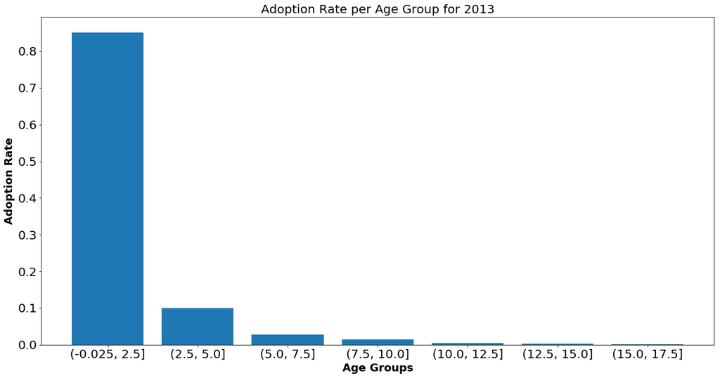

|  | AgeGrp | Adopted | Rate |
| --- | --- | --- | --- |
| 0 | (-0.025, 2.5] | 1123 | 0.850758 |
| 4 | (2.5, 5.0] | 132 | 0.100000 |
| 5 | (5.0, 7.5] | 36 | 0.027273 |
| 6 | (7.5, 10.0] | 19 | 0.014394 |
| 1 | (10.0, 12.5] | 6 | 0.004545 |
| 2 | (12.5, 15.0] | 3 | 0.002273 |
| 3 | (15.0, 17.5] | 1 | 0.000758 |

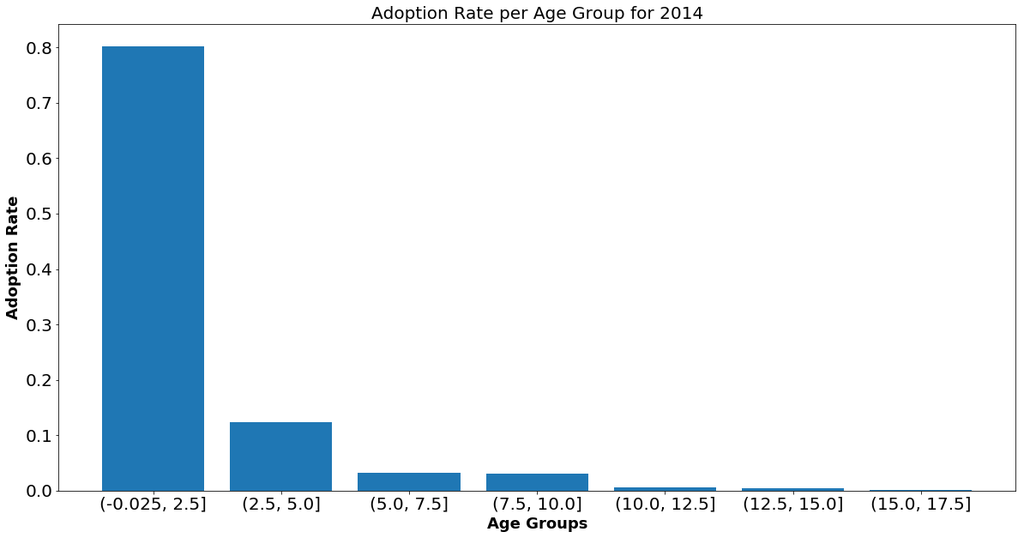

|  | AgeGrp | Adopted | Rate |
| --- | --- | --- | --- |
| 0 | (-0.025, 2.5] | 5610 | 0.801772 |
| 4 | (2.5, 5.0] | 867 | 0.123910 |
| 5 | (5.0, 7.5] | 229 | 0.032728 |
| 6 | (7.5, 10.0] | 215 | 0.030727 |
| 1 | (10.0, 12.5] | 39 | 0.005574 |
| 2 | (12.5, 15.0] | 30 | 0.004288 |
| 3 | (15.0, 17.5] | 7 | 0.001000 |

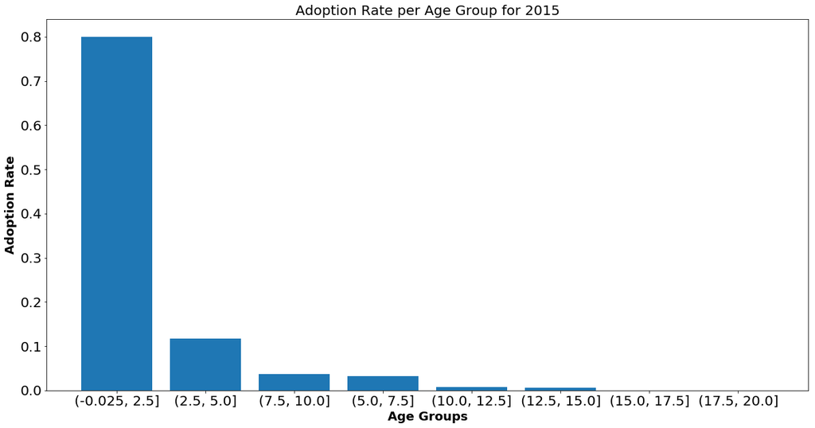

|  | AgeGrp | Adopted | Rate |
| --- | --- | --- | --- |
| 0 | (-0.025, 2.5] | 5876 | 0.799565 |
| 5 | (2.5, 5.0] | 864 | 0.117567 |
| 7 | (7.5, 10.0] | 275 | 0.037420 |
| 6 | (5.0, 7.5] | 237 | 0.032249 |
| 1 | (10.0, 12.5] | 51 | 0.006940 |
| 2 | (12.5, 15.0] | 42 | 0.005715 |
| 3 | (15.0, 17.5] | 3 | 0.000408 |
| 4 | (17.5, 20.0] | 1 | 0.000136 |

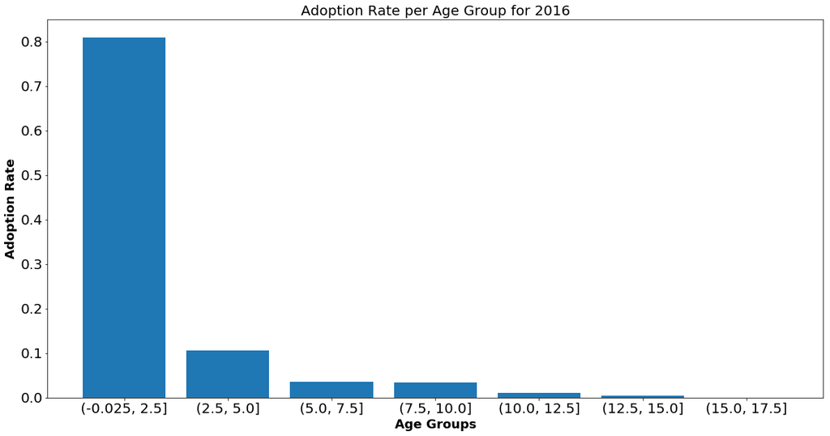

|  | AgeGrp | Adopted | Rate |
| --- | --- | --- | --- |
| 0 | (-0.025, 2.5] | 6430 | 0.808907 |
| 4 | (2.5, 5.0] | 846 | 0.106428 |
| 5 | (5.0, 7.5] | 287 | 0.036105 |
| 6 | (7.5, 10.0] | 269 | 0.033841 |
| 1 | (10.0, 12.5] | 83 | 0.010442 |
| 2 | (12.5, 15.0] | 31 | 0.003900 |
| 3 | (15.0, 17.5] | 3 | 0.000377 |

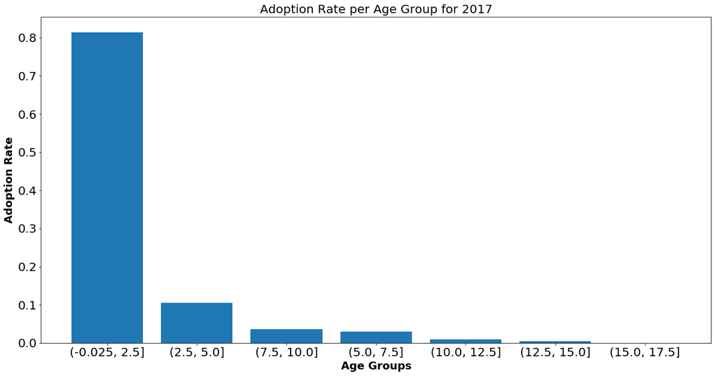

|  | AgeGrp | Adopted | Rate |
| --- | --- | --- | --- |
| 0 | (-0.025, 2.5] | 6482 | 0.813708 |
| 4 | (2.5, 5.0] | 838 | 0.105197 |
| 6 | (7.5, 10.0] | 289 | 0.036279 |
| 5 | (5.0, 7.5] | 238 | 0.029877 |
| 1 | (10.0, 12.5] | 78 | 0.009792 |
| 2 | (12.5, 15.0] | 39 | 0.004896 |
| 3 | (15.0, 17.5] | 2 | 0.000251 |

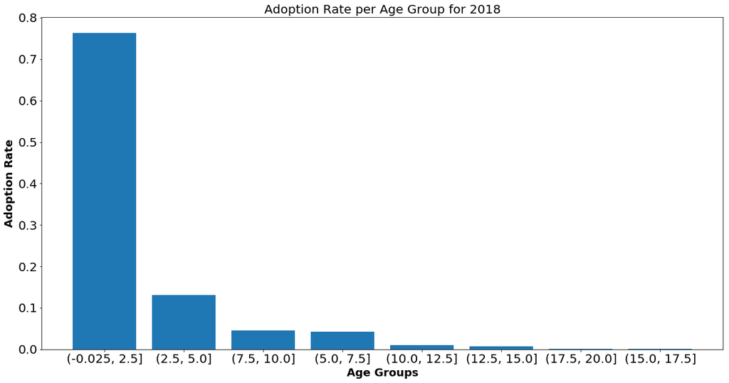

|  | AgeGrp | Adopted | Rate |
| --- | --- | --- | --- |
| 0 | (-0.025, 2.5] | 1278 | 0.762985 |
| 5 | (2.5, 5.0] | 220 | 0.131343 |
| 7 | (7.5, 10.0] | 76 | 0.045373 |
| 6 | (5.0, 7.5] | 70 | 0.041791 |
| 1 | (10.0, 12.5] | 17 | 0.010149 |
| 2 | (12.5, 15.0] | 11 | 0.006567 |
| 4 | (17.5, 20.0] | 2 | 0.001194 |
| 3 | (15.0, 17.5] | 1 | 0.000597 |

```python
# For each year
for x in range(len(td)):

    # Tidy the data for analyzing only the adoptions of each age group
    t = data.loc[(data['YearOut']==td['YearOut'][x]) & (data['Adopted'] == True)]
    tt = t.groupby(['AgeGrp'], as_index=False)['Adopted'].count()

    # Add a column for adoption rate for each age group
    tt['Rate'] = [a/td['Adopted'][x] for a in tt['Adopted']]

    # Sort by Rate since age group is stored as a string and cannot be properly sorted
    tt = tt.sort_values(by='Rate', ascending=False)

    # Plot rate for each age group
    plt.figure(figsize=(20,10))
    plt.bar(tt['AgeGrp'],tt['Rate'])
    plt.title('Adoption Rate per Age Group for ' + str(td['YearOut'][x]), fontsize=20)
    plt.xlabel('Age Groups', fontweight='bold', fontsize=18)
    plt.ylabel('Adoption Rate', fontweight='bold', fontsize=18)
    plt.show()

    display(tt)
```

## Data Transformation

Since our distribution looks very imbalanced, let's see if we can standardize our data across age to get a better understanding of the likelihood of a younger animal being adopted. Instead of standardizing over year, we will take the full range of data as is because year by year, the frequencies are almost always the same.

```python
# Use sklearn's preprocessing module to standardize the Age variable.
data['StdAge'] = preprocessing.scale(data['Age'])
data.head()
```

|  | Animal | Age | AgeGrp | Sex | Breed | Color | DaysIn | YearOut | Adopted | StdAge |
| --- | --- | --- | --- | --- | --- | --- | --- | --- | --- | --- |
| 0 | Dog | 10.0 | (7.5, 10.0] | Neutered Male | Spinone Italiano Mix | Yellow/White | 0.588194 | 2017 | False | 2.628868 |
| 1 | Dog | 7.0 | (5.0, 7.5] | Neutered Male | Spinone Italiano Mix | Yellow/White | 1.259722 | 2014 | False | 1.617704 |
| 2 | Dog | 6.0 | (5.0, 7.5] | Neutered Male | Spinone Italiano Mix | Yellow/White | 1.113889 | 2014 | False | 1.280649 |
| 3 | Dog | 10.0 | (7.5, 10.0] | Neutered Male | Dachshund | Tricolor | 4.970139 | 2014 | False | 2.628868 |
| 4 | Dog | 16.0 | (15.0, 17.5] | Neutered Male | Shetland Sheepdog | Brown/White | 0.119444 | 2013 | False | 4.651196 |

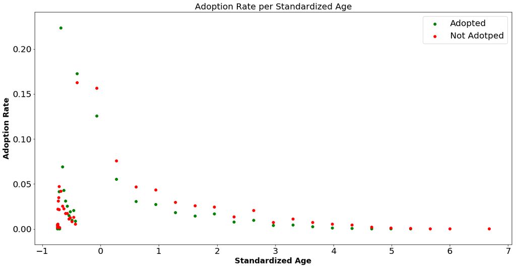

```python
ad = data.loc[data['Adopted']==True]
ab = data.loc[data['Adopted']==False]

adc = ad.groupby(['StdAge'], as_index=False)['Adopted'].count()
abc = ab.groupby(['StdAge'], as_index=False)['Adopted'].count()

plt.figure(figsize=(20,10))
plt.scatter(adc['StdAge'], adc['Adopted']/len(ad), color='green', label='Adopted')
plt.scatter(abc['StdAge'], abc['Adopted']/len(ab), color='red', label='Not Adotped')
plt.legend(fontsize=20)
plt.title('Adoption Rate per Standardized Age', fontsize=20)
plt.xlabel('Standardized Age', fontweight='bold', fontsize=18)
plt.ylabel('Adoption Rate', fontweight='bold', fontsize=18)
plt.show()
```

## Regression Analysis and Visualization

We will now attempt to perform a linear regression on our data so we can predict what the future will hold for the current trends. If applicable, we will add an interaction term for the most likely influencing factor in adoption.

Let's start by first obtaining a fit for our model. We can do so through sklearn's LinearRegression module.

```python
# Make age a continuous variable to carry out a linear regression
X = np.array(data['Age']).reshape(-1,1)
y = data['Adopted']
fit = LinReg().fit(X,y)

display(fit.coef_)
display(fit.intercept_)
```

```
array([-0.02611562])
```

```
0.5014423737610298
```

From our coefficient for Age, we can tell that there's an average decrease in the likelihood of adoption the older an animal becomes. However, our intercept tells us that even the youngest of shelter animals has around a 50% chance of being adopted.

Now let's try and see if we can incorporate a meaningful [interaction term](https://machinelearningmastery.com/how-to-one-hot-encode-sequence-data-in-python/) by factoring in the breeds. An interaction term is a parameter of a model that will tell if the independent features of the model have more of a combined effect on the regression.

Before we can jump right into it, we'll need to redefine our category for Breed with something more meaningful (aka numeric) that we can actually run through a model of best fit. [One-hot encoding](https://machinelearningmastery.com/how-to-one-hot-encode-sequence-data-in-python/) is the process of transforming a categorical variable into binary vectors and then using those vectors to perform numerical analysis, in our case for finding an interaction term for linear regression.

We will get our one-hot encoding of the Breed category by utilizing pandas' own get_dummies method. From there we'll combine our features of Age and Breed and fit them against the Adopted category to find out if the combination of the two has an effect on adoption.

```python
# One-hot encode Breed
breeds = pd.get_dummies(data=data['Breed'], drop_first=True)

# Create features variable
Xi = data['Age'].to_frame().join(breeds)

# Fit model for interaction term
X_train, X_test, Y_train, Y_test = train_test_split(Xi, y, test_size = .20, random_state = 40)
model = LinReg().fit(X_train, Y_train)

display(model.coef_)
display(model.intercept_)
```

```
array([-2.61695879e-02, -3.57631308e-01, -1.03798312e+12, ...,
        0.00000000e+00, -1.00033951e+00, -5.23896217e-02])
```

```
1.1836683977613234
```

## Classification

[Gradient descent](https://ml-cheatsheet.readthedocs.io/en/latest/gradient_descent.html) is an optimization algorithm used to minimize a function by iteratively descending down the gradient of the said function. For our purpose, we'll be using gradient descent to minimize the cost needed to update our coefficients for a logistic regression model.

```python
def logGD(X, y, T, alpha):

    # Create weights for model
    thetas = np.zeros(X.shape[1])

    for i in range(T):

        predictions = np.dot(X, thetas)

        # Sigmoid function on the predictions
        sigmoid = 1 / (1 + np.exp(-(predictions)))

        # Calculate gradient by taking the average cost derivative of each feature and multiplying by learning rate
        gradient = alpha*(np.dot(X.T, (sigmoid - y))/len(X))

        # Subtract gradient from weights to minimize cost
        thetas = thetas -  gradient

    return thetas

logGD(X, y, 100, .01)
```

[output not shown]

This function, logGD, will produce the minimized parameters for our logistic regression function.

## Summarize Findings

The point of this guide was not to chastise those who adopt puppies or kittens. This is not a PSA for every reader to head to their nearest shelter and adopt the lot. Rather the point is to raise awareness on the state of adoption across the country. Several shelter animals who have been through traumatic experiences, illnesses, or abandonment are not given a chance because of the puppy dog eyes effect. Although we have not explained why it exists, it is no surprise that many adopting families and individuals can find the positives of adopting a younger animal. Reasons vary from the amount of space they take up, the various first-time experiences that can be shared, the care of small children, and more. If you are in a position to care for an animal in need, consider rescuing an older companion from your local shelter.